# **Collaborative Filtering With TensorFlow, ML1 Final Project, Group 2**

**Ellie Stewart, Junny Choi, and Payton Stewart**

## Model Description and Applications

Collaborative filtering (CF) is a recommendation approach that predicts what a user might like by analyzing how other users behave. For example, if two people have shown similar preferences in the past, they are likely to agree again in the future. (If many people who liked Movie A also liked Movie B, then the system might recommend Movie B to you if you liked Movie A.)

Instead of relying on item descriptions (like genre or category), collaborative filtering focuses on patterns in user behavior such as ratings, clicks, purchases, or views. These patterns are used to detect similarities between users or between items. Based on those similarities, the system recommends new items that similar users have already liked.

Collaborative filtering methods are divided into memory-based and model-based approaches. Memory-based methods make recommendations by directly comparing users or items using similarity measures. User-based filtering finds similar users, while item-based filtering finds similar items based on past interactions. Model-based methods instead learn patterns from the user–item data using machine learning techniques. A common example is matrix factorization, which represents users and items with lower-dimensional latent features to predict missing preferences more effectively.

According to IBM’s overview, collaborative filtering is widely adopted in recommendation systems because it remains effective even when data is limited, as long as sufficient user interaction data is available. It is commonly used in e-commerce, streaming services, social media, news platforms, and online advertising to personalize content and product suggestions based on patterns in user behavior.

Reference: IBM. What is collaborative filtering? https://www.ibm.com/think/topics/collaborative-filtering

## Key Components for Memory Based CF

**1. User Item Matrix**

Let the user item rating matrix be

$$ R \in \mathbb{R}^{m \times n} $$

with observed entries indexed by

$$ \Omega \subseteq \{1,\dots,m\} \times \{1,\dots,n\} $$

(Interpretation: All the data is organized into a table where each row represents a user and each column represents an item (such as a movie or product). The values in the table are the ratings users gave to items, which helps show their preferences.)

Example from IBM (https://www.ibm.com/think/topics/collaborative-filtering):

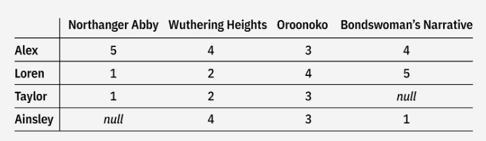

**2. Similarity Function**

Similarity between users or items is computed directly from observed ratings.

Cosine similarity

$$ sim(u,v) = \frac{\sum_{i \in \Omega_u \cap \Omega_v} r_{ui} r_{vi}} {\sqrt{\sum_{i \in \Omega_u} r_{ui}^2} \sqrt{\sum_{i \in \Omega_v} r_{vi}^2}} $$

Pearson correlation

$$ sim(u,v) = \frac{\sum_{i \in \Omega_u \cap \Omega_v}(r_{ui}-\bar r_u)(r_{vi}-\bar r_v)} {\sqrt{\sum_{i \in \Omega_u \cap \Omega_v}(r_{ui}-\bar r_u)^2} \sqrt{\sum_{i \in \Omega_u \cap \Omega_v}(r_{vi}-\bar r_v)^2}} $$

(Interpretation: The system compares users to determine how similar their tastes are. This is done by looking at how they rated the same items. If two users tend to rate the same items similarly, the system considers them to have similar preferences.)

3. **Neighborhood Selection**

For a target user $u$, define the neighborhood $N(u)$ as the top $k$ most similar users who have rated item $i$.

(Interpretation: For each user, the system identifies a small group of other users whose preferences are the most similar. These users form a “neighborhood” that will be used to help make recommendations.)

4. **Prediction Function**

Using cosine similarity

$$ \hat r_{ui} = \frac{\sum_{v \in N(u)} sim(u,v) r_{vi}} {\sum_{v \in N(u)} |sim(u,v)|} $$

Using Pearson correlation

$$ \hat r_{ui} = \bar r_u + \frac{\sum_{v \in N(u)} sim(u,v)(r_{vi}-\bar r_v)} {\sum_{v \in N(u)} |sim(u,v)|} $$

Memory based collaborative filtering computes predictions directly from similarity without learning latent parameters.

(Interpretation: To estimate how a user might rate an item they have not rated yet, the system looks at how the similar users rated that item. The ratings from the most similar users have the strongest influence on the prediction.)

## Algorithm for Memory Based CF

Given $R$ and $\Omega$

1. Compute similarities  
   For all user pairs $(u,v)$ compute $sim(u,v)$.
2. Select neighborhood  
   For each target $(u,i)$ construct $N(u)$ as the top $k$ similar users who rated item $i$.
3. Predict ratings  
   Compute

$$ \hat r_{ui} = \frac{\sum_{v \in N(u)} sim(u,v) r_{vi}} {\sum_{v \in N(u)} |sim(u,v)|} $$

Components:

$\hat{r}_{ui}$ : The predicted rating for user u on item i.

$N(u)$ : The neighborhood, which is the group of users who are most similar to user u.

$sim(u,v)$ : The similarity score (obtained from cosine similarity/pearson correlation) between user u and another user v. Higher values mean their preferences are more similar.

$r_{vi}$: The rating that user v gave to item i.

4. Output

The predicted rating $\hat r_{ui}$ is used to rank items and recommend the highest scoring items.

## Key Components for Model Based

1. **User Rating Matrix**

Just like in the memory based approach, the data is first organized into a table where rows represent users and columns represent items. The values in the table are the ratings users gave to items.

Let the rating matrix be

$$ R \in \mathbb{R}^{m \times n} $$

with observed entries indexed by Ω

2. **Latent Factor Representation**

Each user and item is represented in a shared $k$ dimensional latent space.

User latent vector

$$ u_u \in \mathbb{R}^k $$

Item latent vector

$$ v_i \in \mathbb{R}^k $$

Stacked matrices

$$ U \in \mathbb{R}^{m \times k}, \quad V \in \mathbb{R}^{n \times k} $$

Low rank approximation

$$ R \approx U V^T $$

(Interpretation: Unlike memory based methods that compare users directly using their ratings, model based approaches learn hidden factors that represent user preferences and item characteristics, allowing the model to make predictions even when there is little overlap in ratings. For example, in a movie system these hidden factors might represent things like preference for action, romance, or comedy. Each user and each item is represented by these hidden factors.)

3. **Prediction Function**

$$ \hat r_{ui} = u_u^T v_i $$

With bias terms

$$ \hat r_{ui} = \mu + b_u + b_i + u_u^T v_i $$

(Interpretation: The model predicts how a user might rate an item by combining the user’s learned preferences with the characteristics of the item. If a user’s preferences match the item’s characteristics, the predicted rating will be higher. Bias terms adjust the prediction by accounting for users who generally rate higher or lower than average and items that are generally rated higher or lower by everyone.)

4. **Objective Function**

$$ \min_{U,V} \sum_{(u,i)\in\Omega} (r_{ui} - u_u^T v_i)^2 + \lambda (||U||_F^2 + ||V||_F^2) $$

(Interpretation: The model adjusts its internal parameters to make its predictions as close as possible to the real ratings in the data. During training, it repeatedly improves the predictions while also preventing the model from becoming too complex.)

## Algorithm for Model Based CF

Given $R$ and $\Omega$, train a regularized matrix factorization model with SGD (stochastic gradient descent):

1. **Initialize parameters**

Initialize $U$ and $V$ with small random values. The model starts by assigning small random values to represent the hidden preferences of users and the hidden characteristics of items. At this stage, the model does not yet know anything about the data.

2. **Minimize objective**

Solve

$$ \min_{U,V} \sum_{(u,i)\in\Omega} (r_{ui} - u_u^T v_i)^2 + \lambda (||U||_F^2 + ||V||_F^2) $$

Components:

$r_{ui}$ : The actual rating that user u gave to item i.

$u_u^T v_i$ : The predicted rating from the model based on the user’s preferences and the item’s characteristics.

$(r_{ui} - u_u^T v_i)^2$ : The prediction error. It measures how far the model’s prediction is from the real rating. Squaring it makes larger mistakes count more.

$\lambda (||U||_F^2 + ||V||_F^2)$: A regularization term that keeps the model from becoming too complex and helps prevent overfitting.

3. **Optimization (SGD example)**

For each observed entry $(u,i)\in\Omega$

$$ e_{ui} = r_{ui} - u_u^T v_i $$

$$ u_u \leftarrow u_u + \eta (e_{ui} v_i - \lambda u_u) $$

$$ v_i \leftarrow v_i + \eta (e_{ui} u_u - \lambda v_i) $$

where $\eta$ is the learning rate and $\lambda$ is the regularization strength.

(Interpretation: The model looks at each known rating and calculates the error. The model then slightly adjusts the user and item factors to reduce this error and improve future predictions. The learning rate controls how big the adjustments are when the model updates its parameters. Regularization helps prevent the model from becoming too complex, which helps avoid overfitting and improves generalization.)

4. **Output**

After training, predict with

$$ \hat r_{ui} = u_u^T v_i $$

and recommend items with the highest predicted scores.

(Interpretation: After the model finishes training, it uses the learned user and item factors to predict ratings for items a user has not rated yet. The system then recommends the items with the highest predicted ratings, since those are the ones the user is most likely to enjoy.)

## Available Packages

There are several packages available for collaborative filtering. Surprise provides built-in implementations of kNN and SVD for traditional memory-based and matrix factorization methods. The implicit library focuses on large-scale recommendation with implicit feedback using algorithms like ALS and BPR. LightFM supports hybrid models that combine collaborative filtering with content features. More flexible frameworks like TensorFlow or PyTorch allow custom and neural network–based recommendation models.

For this project, we chose TensorFlow because it gives us more control over how the model is built. It allows us to implement matrix factorization, and it scales well for larger datasets. It also makes it easier to extend the model later if we want to experiment with additional features. TensorFlow also provides many built in functions that accommodate different modeling needs, such as Poisson and other loss functions, which can be useful when implementing collaborative filtering models.

## Basic Example (User - Movie Ratings)

For a basic example, we will simulate a movie recommendation system using model based collaborative filtering. We first generate a synthetic dataset where 29 users rate 100 movies on a scale from 1 to 5 and treat this complete matrix as the ground truth. To mimic real world recommendation data, we randomly remove about 60 percent of the ratings to create an observed matrix with missing values. We then convert the observed ratings into user movie rating pairs and train a matrix factorization model in TensorFlow, where each user and movie is represented by a latent embedding along with bias terms, and the model learns to predict ratings by minimizing squared error with regularization. After training, we reconstruct the full predicted rating matrix, evaluate the model by comparing predictions to the hidden ground truth ratings using RMSE and MAE, and finally generate top movie recommendations for a few selected users while also showing the true ratings for those recommended movies.

```python
import numpy as np
import pandas as pd
import tensorflow as tf

# Set seed so results are reproducible
seed = 31017
np.random.seed(seed)
tf.random.set_seed(seed)

# Define users (29)
users = [
"Junny","Ellie","Payton","Francisco","Alice","Bob","Carol","Dave","Eve","Frank",
"Grace","Henry","Ivy","Jack","Karen","Leo","Maya","Nina","Oscar","Paul",
"Quinn","Rita","Sam","Tina","Uma","Victor","Wendy","Xavier","Yara"
]

# Define movies (100)
movies = [
"Titanic","Avatar","Batman","Toy Story","Inception","Matrix","Interstellar",
"Frozen","Joker","Avengers","Spider-Man","The Dark Knight","La La Land",
"Jurassic Park","Star Wars","Harry Potter","Lord of the Rings","Shrek",
"Gladiator","Top Gun","Iron Man","Thor","Black Panther","Captain Marvel",
"Guardians of the Galaxy","Doctor Strange","Ant-Man","Deadpool",
"Wonder Woman","Aquaman","The Flash","Superman","Minions","Cars",
"Finding Nemo","Inside Out","Up","Coco","Ratatouille","Monsters Inc",
"Kung Fu Panda","Madagascar","Ice Age","How to Train Your Dragon",
"The Lion King","Aladdin","Beauty and the Beast","Mulan","Tangled","Moana",

"The Godfather","Pulp Fiction","Forrest Gump","The Shawshank Redemption",
"The Social Network","Fight Club","The Departed","The Prestige",
"Whiplash","Parasite","No Country for Old Men","Dune",
"Mission Impossible","The Bourne Identity","Mad Max Fury Road",
"Skyfall","Casino Royale","John Wick","The Hunger Games",
"The Maze Runner","The Incredibles","Big Hero 6","Encanto",
"Luca","Turning Red","Brave","Soul",
"A Quiet Place","Get Out","Us","The Conjuring",
"It","The Ring","The Exorcist","Hereditary",
"Mean Girls","Clueless","Legally Blonde","The Devil Wears Prada",
"Notting Hill","Love Actually","Pretty Woman","The Notebook",
"Ocean's Eleven","Catch Me If You Can","The Wolf of Wall Street",
"The Big Short","Moneyball","The Truman Show"
]

num_users = len(users)
num_movies = len(movies)

# Create full rating matrix with integer ratings (1-5)
ground_truth = np.random.randint(1, 6, size=(num_users, num_movies))

ground_truth_df = pd.DataFrame(
    ground_truth,
    index=users,
    columns=movies
)

# Copy matrix and convert to float so NaN can exist
observed_df = ground_truth_df.astype(float)

# Randomly remove ratings
drop_rate = 0.6
drop_mask = np.random.rand(num_users, num_movies) < drop_rate
observed_df.values[drop_mask] = np.nan

# Store matrices
R_true = ground_truth_df.values
R_obs = observed_df.values

# Show preview
preview_movies = movies[:8]

print("Ground Truth Ratings")
display(ground_truth_df.loc[:, preview_movies].head(4))

print("Observed Ratings with Missing Values")
display(observed_df.loc[:, preview_movies].head(4))
```

```
Ground Truth Ratings
```

|  | Titanic | Avatar | Batman | Toy Story | Inception | Matrix | Interstellar | Frozen |
| --- | --- | --- | --- | --- | --- | --- | --- | --- |
| Junny | 3 | 3 | 5 | 5 | 4 | 4 | 5 | 3 |
| Ellie | 5 | 5 | 4 | 5 | 4 | 1 | 3 | 2 |
| Payton | 5 | 4 | 3 | 4 | 5 | 1 | 2 | 5 |
| Francisco | 2 | 3 | 3 | 3 | 1 | 4 | 5 | 5 |

```
Observed Ratings with Missing Values
```

|  | Titanic | Avatar | Batman | Toy Story | Inception | Matrix | Interstellar | Frozen |
| --- | --- | --- | --- | --- | --- | --- | --- | --- |
| Junny | 3.0 | NaN | 5.0 | NaN | NaN | NaN | NaN | 3.0 |
| Ellie | 5.0 | 5.0 | NaN | NaN | 4.0 | 1.0 | 3.0 | NaN |
| Payton | 5.0 | NaN | NaN | NaN | NaN | 1.0 | NaN | NaN |
| Francisco | NaN | 3.0 | 3.0 | 3.0 | NaN | NaN | 5.0 | 5.0 |

```python
# Identify all user–movie pairs with ratings and extract their rating values
obs_u, obs_i = np.where(~np.isnan(R_obs))
obs_r = R_obs[obs_u, obs_i]

# Convert the extracted data into TensorFlow tensors for model training
u_ids = tf.constant(obs_u, dtype=tf.int32)
i_ids = tf.constant(obs_i, dtype=tf.int32)
ratings = tf.constant(obs_r, dtype=tf.float32)

# Latent dimension for embeddings:
# A higher value gives the model more hidden features to represent user preferences
# and movie characteristics, allowing it to capture more complex patterns.
# A lower value creates a simpler model that trains faster but may miss important relationships.
k = 8

# Global mean rating (should be around 3, since ratings are 1-5)
mu = tf.Variable(tf.reduce_mean(ratings), dtype=tf.float32)

# User and movie latent factor matrices
U = tf.Variable(tf.random.normal([num_users, k], stddev=0.05))
V = tf.Variable(tf.random.normal([num_movies, k], stddev=0.05))

# Bias terms for users and movies:
# User bias captures how a user tends to rate items overall
# (for example, some users consistently give higher or lower ratings).
# Movie bias captures how a movie tends to be rated across all users
# (for example, some movies are generally liked more than others).
b_u = tf.Variable(tf.zeros([num_users]))
b_i = tf.Variable(tf.zeros([num_movies]))

# Prediction function for user–movie pairs
def predict(u, i):
    u_vec = tf.gather(U, u)
    i_vec = tf.gather(V, i)

    return (
        mu
        + tf.gather(b_u, u)
        + tf.gather(b_i, i)
        + tf.reduce_sum(u_vec * i_vec, axis=1)
    )

# Learning rate:
# A higher learning rate updates parameters more quickly but can make training unstable.
# A lower learning rate results in slower but more stable learning.
optimizer = tf.keras.optimizers.Adam(0.01)

# Regularization:
# A higher value penalizes large parameter values more strongly,
# keeping predictions closer to the global mean and reducing overfitting.
# A lower value allows the model to fit the data more aggressively,
# which can produce more extreme predictions but may overfit the training data.
reg = 0.005

# Number of training epochs:
# More epochs allow the model to learn patterns more thoroughly but increase training time.
# Fewer epochs reduce training time but may stop the model before it fully learns the data.
for epoch in range(1500):

    with tf.GradientTape() as tape:

        pred = predict(u_ids, i_ids)
        mse = tf.reduce_mean((ratings - pred) ** 2)

        l2 = (
            tf.reduce_sum(U**2)
            + tf.reduce_sum(V**2)
            + tf.reduce_sum(b_u**2)
            + tf.reduce_sum(b_i**2)
        )

        loss = mse + reg * l2

    grads = tape.gradient(loss, [U, V, b_u, b_i, mu])
    optimizer.apply_gradients(zip(grads, [U, V, b_u, b_i, mu]))

    if epoch % 200 == 0:
        print(epoch, mse.numpy())

# Reconstruct the full predicted rating matrix
R_pred = (
    mu.numpy()
    + b_u.numpy()[:, None]
    + b_i.numpy()[None, :]
    + np.dot(U.numpy(), V.numpy().T)
)

# Keep predictions within the rating scale
R_pred = np.clip(R_pred, 1, 5)

pred_df = pd.DataFrame(np.round(R_pred, 2), index=users, columns=movies)

# Evaluate predictions on ratings that were hidden during training
heldout_mask = np.isnan(R_obs)

true_heldout = R_true[heldout_mask]
pred_heldout = R_pred[heldout_mask]

rmse = np.sqrt(np.mean((true_heldout - pred_heldout) ** 2))
mae = np.mean(np.abs(true_heldout - pred_heldout))

print("Evaluation on hidden ratings")
print(f"RMSE: {rmse:.3f}")
print(f"MAE:  {mae:.3f}")

# Show sample comparisons of predicted vs true ratings
heldout_u, heldout_i = np.where(heldout_mask)

sample_idx = np.random.choice(len(heldout_u), 10, replace=False)

comparison_df = pd.DataFrame({
    "User":[users[heldout_u[i]] for i in sample_idx],
    "Movie":[movies[heldout_i[i]] for i in sample_idx],
    "True Rating":[R_true[heldout_u[i], heldout_i[i]] for i in sample_idx],
    "Predicted":[np.round(R_pred[heldout_u[i], heldout_i[i]],2) for i in sample_idx]
})

comparison_df
```

```
0 2.0517898
200 0.7914699
400 0.7834241
600 0.7834797
800 0.78349304
1000 0.78349525
1200 0.7834873
1400 0.7834907
Evaluation on hidden ratings
RMSE: 1.530
MAE:  1.306
```

|  | User | Movie | True Rating | Predicted |
| --- | --- | --- | --- | --- |
| 0 | Ivy | Avengers | 3 | 3.16 |
| 1 | Yara | Love Actually | 2 | 2.97 |
| 2 | Tina | The Dark Knight | 3 | 3.68 |
| 3 | Bob | Tangled | 2 | 3.65 |
| 4 | Maya | Moana | 1 | 1.98 |
| 5 | Wendy | Iron Man | 5 | 2.93 |
| 6 | Karen | Deadpool | 2 | 2.57 |
| 7 | Nina | No Country for Old Men | 1 | 2.86 |
| 8 | Xavier | Minions | 3 | 2.75 |
| 9 | Frank | Mad Max Fury Road | 3 | 3.73 |

The model gets an RMSE of about 1.53 and an MAE of about 1.31, meaning predictions are typically around 1 to 1.5 rating points away from the true value on a 1 to 5 scale, which is relatively large. Although this data is synthetic, we could improve the model by tuning model parameters such as increasing the latent dimension, adjusting regularization, or training for more epochs so the model can capture more variation in the ratings.

```python
# Generate recommendations for selected users
selected_users = ["Junny","Ellie","Payton","Francisco"]

for user in selected_users:

    user_id = users.index(user)

    # Identify movies the user did not rate
    unrated = np.where(np.isnan(R_obs[user_id]))[0]
    scores = R_pred[user_id, unrated]

    # Rank movies by predicted rating
    recommendations = sorted(
        [(movies[i], scores[j], R_true[user_id, i]) for j, i in enumerate(unrated)],
        key=lambda x: -x[1]
    )

    print(f"\nTop 3 movie recommendations for {user}")

    for movie, pred_score, true_score in recommendations[:3]:
        print(f"{movie:25} predicted: {pred_score:.2f} | true rating: {true_score}")
```

```
Top 3 movie recommendations for Junny
Clueless                  predicted: 4.39 | true rating: 5
Get Out                   predicted: 4.07 | true rating: 5
Iron Man                  predicted: 4.02 | true rating: 2

Top 3 movie recommendations for Ellie
The Flash                 predicted: 3.95 | true rating: 5
Guardians of the Galaxy   predicted: 3.88 | true rating: 1
Big Hero 6                predicted: 3.88 | true rating: 1

Top 3 movie recommendations for Payton
Interstellar              predicted: 3.67 | true rating: 2
Inside Out                predicted: 3.59 | true rating: 5
Up                        predicted: 3.59 | true rating: 2

Top 3 movie recommendations for Francisco
Titanic                   predicted: 4.17 | true rating: 2
Madagascar                predicted: 3.96 | true rating: 4
Notting Hill              predicted: 3.91 | true rating: 1
```

We can see that at least one of the top three recommended movies for each user has a ground truth rating of 4 or higher. This suggests that the user would likely enjoy at least one of the three movies recommended by the model.

## Real-World Application

### **Objective**

The overall aim of this application is to uncover latent structural patterns correlated with violence across African countries and to evaluate whether matrix factorization methods—adapted from collaborative filtering in recommender systems—can improve short-term forecasting of conflict frequency. Rather than modeling each country independently, this approach treats violence as a structured cross-national system driven by shared but unobserved regional dynamics. Using collaborative filtering, if possible, we hope to uncover latent conflict regimes and quantify structural similarity across African countries. The final goal is to see if these latent factors enhance predictive performance relative to traditional time-series baselines.  
Using Africa is a conscious choice. We understand the way many national boarders were drawn (through European imperialism) intuitively would contribute to conflicts having spillover effects, which could be an important aspect of the cross-national system similarity found in this exercise. Spillover effects have also been proven in earlier literature through a natural resource mechanism. See ["This Mine Is Mine! How Minerals Fuel Conflict In Africa"](https://www.aeaweb.org/articles?id=10.1257/aer.20150774). Africa also provides an ideal context because 1) the data is available and 2) conflict dynamics exhibit: insurgency waves, coups and regime instability, and regional contagion effects. This goes beyond spillovers. We choose just one region because it reduces heterogeneity relative to a global dataset.

### **Dataset Description**

The analysis uses aggregated country–week data for Africa, current as of Feb 14, 2026, from the Armed Conflict Location & Event Data Project (ACLED). It can be found [here](https://acleddata.com/aggregated/aggregated-data-africa).  
The original dataset contains over 265,000 observations of the number of events per country per week across African states. All states in continental Africa except South Sudan have data going back to Jan 1997. South Sudan coverage begins in Jan 2011. The rest of the columns we deem of note are EVENT_TYPE, SUB_EVENT_TYPE, EVENTS, FATALITIES, CENTROID_LATITUDE, and CENTROID_LONGITUDE. According to ACLED's codebook, event types included in this dataset are battles, protests, riots, explosions/remote violence, violence against civilians, and strategic developments. Definitions of each are as follows:  
**Battles:** a violent interaction between two organized armed groups at a particular time and location. Battles can occur between armed and organized state, non-state, and external groups, and in any combination thereof. There is no fatality minimum necessary for inclusion.  
**Protests:** an in-person public demonstration of three or more participants in which the participants do not engage in violence, though violence may be used against them. Events include individuals and groups who peacefully demonstrate against a political entity, government institution, policy, group, tradition, business, or other private institution. The following are not recorded as Protests events: symbolic public acts such as displays of flags or public prayers (unless they are accompanied by a demonstration); legislative protests, such as parliamentary walkouts or members of parliaments staying silent; strikes (unless they are accompanied by a demonstration); and individual acts such as self-harm actions like individual immolations or hunger strikes.  
**Riots:** violent events where demonstrators or mobs of three or more engage in violent or destructive acts, including but not limited to physical fights, rock throwing, property destruction, etc. They may engage individuals, property, businesses, other rioting groups, or armed actors.  
**Explosions/Remote Violence:** incidents in which one side uses weapon types that, by their nature, are at range and widely destructive. The weapons used in Explosions/Remote violence events are explosive devices, including but not limited to: bombs, grenades, IEDs, artillery fire or shelling, missile attacks, air or drone strikes, and other widely destructive heavy weapons or chemical weapons. Suicide attacks using explosives also fall under this category. When an ‘Explosions/Remote violence event is reported in the context of an ongoing battle, it is merged and recorded as a single Battles event.  
**Violence Against Civilians:** violent events where an organized armed group inflicts violence upon unarmed non-combatants. By definition, civilians are unarmed and cannot engage in political violence. Therefore, the violence is understood to be asymmetric as the perpetrator is assumed to be the only actor capable of using violence in the event. The perpetrators of such acts include state forces and their affiliates, rebels, militias, and external/other forces.  
**Strategic Developments:** This event type captures contextually important information regarding incidents and activities of groups that are not recorded as Political violence or Demonstrations events, yet may trigger future events or contribute to political dynamics within and across states. The inclusion of such events is limited, as their purpose is to capture pivotal events within the broader political landscape. They typically include a disparate range of events, such as recruitment drives, looting, and incursions, as well as the location and date of peace talks and the arrests of high-ranking officials or large groups.

Each event type has sub event types that we could have honed in on for severity, but the above is clearly hierarchial, which is very necessary for collaborative filtering because we need the data to be ordinal. So we sacrifice granularity for accuracy. Further descriptions can again be found at ACLED.

### **Load and Clean Data**

```python
import pandas as pd
from google.colab import drive

drive.mount('/content/drive', force_remount=True)

file_path = '/content/drive/MyDrive/Africa_aggregated_data_up_to-2026-02-14.xlsx'

df = pd.read_excel(file_path)

print(df.info())
display(df.head())
```

```
<class 'pandas.core.frame.DataFrame'>
RangeIndex: 265548 entries, 0 to 265547
Data columns (total 13 columns):
 #   Column               Non-Null Count   Dtype
---  ------               --------------   -----
 0   WEEK                 265548 non-null  datetime64[ns]
 1   REGION               265548 non-null  object
 2   COUNTRY              265548 non-null  object
 3   ADMIN1               265548 non-null  object
 4   EVENT_TYPE           265548 non-null  object
 5   SUB_EVENT_TYPE       265548 non-null  object
 6   EVENTS               265548 non-null  int64
 7   FATALITIES           265548 non-null  int64
 8   POPULATION_EXPOSURE  170127 non-null  float64
 9   DISORDER_TYPE        265548 non-null  object
 10  ID                   265543 non-null  float64
 11  CENTROID_LATITUDE    265548 non-null  float64
 12  CENTROID_LONGITUDE   265548 non-null  float64
dtypes: datetime64[ns](1), float64(4), int64(2), object(6)
memory usage: 26.3+ MB
None
```

|  | WEEK | REGION | COUNTRY | ADMIN1 | EVENT_TYPE | SUB_EVENT_TYPE | EVENTS | FATALITIES | POPULATION_EXPOSURE | DISORDER_TYPE | ID | CENTROID_LATITUDE | CENTROID_LONGITUDE |
| --- | --- | --- | --- | --- | --- | --- | --- | --- | --- | --- | --- | --- | --- |
| 0 | 2004-10-23 | Northern Africa | Algeria | Adrar | Battles | Armed clash | 1 | 2 | NaN | Political violence | 47.0 | 26.4839 | -1.388 |
| 1 | 2005-04-23 | Northern Africa | Algeria | Adrar | Battles | Armed clash | 1 | 0 | NaN | Political violence | 47.0 | 26.4839 | -1.388 |
| 2 | 2005-06-25 | Northern Africa | Algeria | Adrar | Battles | Armed clash | 1 | 14 | NaN | Political violence | 47.0 | 26.4839 | -1.388 |
| 3 | 2008-12-13 | Northern Africa | Algeria | Adrar | Battles | Armed clash | 1 | 3 | NaN | Political violence | 47.0 | 26.4839 | -1.388 |
| 4 | 2009-04-18 | Northern Africa | Algeria | Adrar | Battles | Armed clash | 1 | 2 | NaN | Political violence | 47.0 | 26.4839 | -1.388 |

**Severity Matrix Construction**

**Fill in empty cells:**

- If an event was recorded but the event_type is blank or not in the list it is assigned 1 (Strategic Development) because something happened, but it wasn't a violent war. This is an assumption that could impact results.
- If there's nothing that week for a country, it is a "Peaceful Week". We add the week to the data and add a 0 because this is still observed information relevant to the latent state.

```python
# Map events
severity_map = {
    'Strategic developments': 1,
    'Protests': 2,
    'Riots': 3,
    'Violence against civilians': 4,
    'Explosions/Remote violence': 5,
    'Battles': 6
}
df['severity_score'] = df['EVENT_TYPE'].map(severity_map).fillna(1)
```

```python
# Aggregate counts and find the max severity reached in that week
aggr_df = df.groupby(['COUNTRY', 'REGION', 'WEEK']).agg(
    weekly_events=('EVENTS', 'sum'),
    max_severity=('severity_score', 'max'),
    total_fatalities=('FATALITIES', 'sum')
).reset_index()

# Sort by country and time to ensure lags are calculated correctly
aggr_df = aggr_df.sort_values(['COUNTRY', 'WEEK'])
```

Our collaborative filtering model won't stand alone. Recalling the main goal being to forecast conflict, we need to feature engineer some lagged indicators, one being if severity escalated.

```python
# 1. Indicator: Was there conflict in the previous week?
# We check if the 'weekly_events' from the previous row for the SAME country is > 0
aggr_df['prev_week_events'] = aggr_df.groupby('COUNTRY')['weekly_events'].shift(1).fillna(0)
aggr_df['has_prior_conflict'] = (aggr_df['prev_week_events'] > 0).astype(int)

# 2. Indicator: Did conflict escalate?
# Compare current max severity to previous max severity
aggr_df['prev_severity'] = aggr_df.groupby('COUNTRY')['max_severity'].shift(1).fillna(0)
aggr_df['is_escalated'] = (aggr_df['max_severity'] > aggr_df['prev_severity']).astype(int)

# 3. Categorical Indicators for TensorFlow (Country and Region)
aggr_df['country_code'] = aggr_df['COUNTRY'].astype('category').cat.codes
aggr_df['region_code'] = aggr_df['REGION'].astype('category').cat.codes
```

```python
# Create a complete grid of all countries and all weeks
all_weeks = aggr_df['WEEK'].unique()
all_countries = aggr_df['COUNTRY'].unique()
grid = pd.MultiIndex.from_product([all_countries, all_weeks], names=['COUNTRY', 'WEEK']).to_frame(index=False)

# Merge our aggregated data back onto this grid
final_df = pd.merge(grid, aggr_df, on=['COUNTRY', 'WEEK'], how='left').fillna(0)
```

```python
final_df["prev_week_events"] = (
    final_df
    .groupby("COUNTRY")["weekly_events"]
    .shift(1)
)
```

The above captures the most severe state of each country in each week and disregards less severe observations.

**Check Cleaning**

```python
raw_total = df['EVENTS'].sum()
clean_total = final_df['weekly_events'].sum()

print(f"Original Events: {raw_total}")
print(f"Aggregated Events: {clean_total}")

if raw_total == clean_total:
    print("No events were lost during aggregation.")
else:
    print("Sums do not match.")
```

```
Original Events: 475008
Aggregated Events: 475008.0
No events were lost during aggregation.
```

```python
test_country = all_countries[0] # This picks the first country in the dataset (e.g., Algeria)
country_data = final_df[final_df['COUNTRY'] == test_country]

print(f"Checking data for: {test_country}")
check_cols = ['WEEK', 'weekly_events', 'max_severity', 'prev_severity', 'is_escalated', 'has_prior_conflict']
display(country_data[check_cols].head(15))
```

```
Checking data for: Algeria
```

|  | WEEK | weekly_events | max_severity | prev_severity | is_escalated | has_prior_conflict |
| --- | --- | --- | --- | --- | --- | --- |
| 0 | 1996-12-28 | 3.0 | 4.0 | 0.0 | 1.0 | 0.0 |
| 1 | 1997-01-04 | 9.0 | 6.0 | 4.0 | 1.0 | 1.0 |
| 2 | 1997-01-11 | 10.0 | 6.0 | 6.0 | 0.0 | 1.0 |
| 3 | 1997-01-18 | 13.0 | 6.0 | 6.0 | 0.0 | 1.0 |
| 4 | 1997-01-25 | 7.0 | 6.0 | 6.0 | 0.0 | 1.0 |
| 5 | 1997-02-01 | 3.0 | 4.0 | 6.0 | 0.0 | 1.0 |
| 6 | 1997-02-08 | 1.0 | 4.0 | 4.0 | 0.0 | 1.0 |
| 7 | 1997-02-15 | 1.0 | 4.0 | 4.0 | 0.0 | 1.0 |
| 8 | 1997-02-22 | 3.0 | 4.0 | 4.0 | 0.0 | 1.0 |
| 9 | 1997-03-29 | 3.0 | 4.0 | 4.0 | 0.0 | 1.0 |
| 10 | 1997-04-05 | 4.0 | 5.0 | 4.0 | 1.0 | 1.0 |
| 11 | 1997-04-12 | 1.0 | 4.0 | 5.0 | 0.0 | 1.0 |
| 12 | 1997-04-19 | 3.0 | 5.0 | 4.0 | 1.0 | 1.0 |
| 13 | 1997-05-10 | 1.0 | 4.0 | 5.0 | 0.0 | 1.0 |
| 14 | 1997-05-24 | 3.0 | 4.0 | 4.0 | 0.0 | 1.0 |

```python
# Check for sparsity
sparsity = (final_df['weekly_events'] == 0).mean()
print(f"Matrix Sparsity: {sparsity:.2%}")
```

```
Matrix Sparsity: 56.70%
```

Half of the observations now are countries where the state was "Peaceful" during the week observed.

**Prepare for TensorFlow by creating integer indices**

```python
# 1. Create unique mapping for Countries and Weeks
final_df['country_id'] = final_df['COUNTRY'].astype('category').cat.codes
final_df['week_id'] = final_df['WEEK'].astype('category').cat.codes

# Replace 0 with NaN first
final_df["REGION"] = final_df["REGION"].replace(0, pd.NA)
final_df["region_code"] = final_df["region_code"].replace(0, pd.NA)

# Fill within each country
final_df["REGION"] = (
    final_df.groupby("COUNTRY")["REGION"]
    .transform(lambda x: x.ffill().bfill())
)

final_df["region_code"] = (
    final_df.groupby("COUNTRY")["region_code"]
    .transform(lambda x: x.ffill().bfill())
)

# 2. Extract the total counts for the Embedding layers
num_countries = final_df['country_id'].nunique()
num_weeks = final_df['week_id'].nunique()

print(f"Ready for TensorFlow:")
print(f"- Unique Countries (Rows): {num_countries}")
print(f"- Unique Weeks (Columns): {num_weeks}")
print(f"- Total Training Samples: {len(final_df)}")

# 3. Save this to a CSV
final_df.to_csv(
    '/content/drive/MyDrive/Africa_Conflict_Cleaned_ML_Ready.csv',
    index=False
)
```

```
Ready for TensorFlow:
- Unique Countries (Rows): 58
- Unique Weeks (Columns): 1521
- Total Training Samples: 88218
```

### **EDA**

```python
import pandas as pd
from google.colab import drive

drive.mount('/content/drive')

file_path = '/content/drive/MyDrive/Africa_Conflict_Cleaned_ML_Ready.csv'

final_df = pd.read_csv(file_path)
final_df = final_df.dropna(subset=["prev_week_events"])
print(final_df.info())
display(final_df.head())
```

```
<class 'pandas.core.frame.DataFrame'>
Index: 88160 entries, 1 to 88217
Data columns (total 14 columns):
 #   Column              Non-Null Count  Dtype
---  ------              --------------  -----
 0   COUNTRY             88160 non-null  object
 1   WEEK                88160 non-null  object
 2   REGION              88160 non-null  object
 3   weekly_events       88160 non-null  float64
 4   max_severity        88160 non-null  float64
 5   total_fatalities    88160 non-null  float64
 6   prev_week_events    88160 non-null  float64
 7   has_prior_conflict  88160 non-null  float64
 8   prev_severity       88160 non-null  float64
 9   is_escalated        88160 non-null  float64
 10  country_code        88160 non-null  float64
 11  region_code         59280 non-null  float64
 12  country_id          88160 non-null  int64
 13  week_id             88160 non-null  int64
dtypes: float64(9), int64(2), object(3)
memory usage: 10.1+ MB
None
```

|  | COUNTRY | WEEK | REGION | weekly_events | max_severity | total_fatalities | prev_week_events | has_prior_conflict | prev_severity | is_escalated | country_code | region_code | country_id | week_id |
| --- | --- | --- | --- | --- | --- | --- | --- | --- | --- | --- | --- | --- | --- | --- |
| 1 | Algeria | 1997-01-04 | Northern Africa | 9.0 | 6.0 | 90.0 | 3.0 | 1.0 | 4.0 | 1.0 | 0.0 | 2.0 | 0 | 1 |
| 2 | Algeria | 1997-01-11 | Northern Africa | 10.0 | 6.0 | 89.0 | 9.0 | 1.0 | 6.0 | 0.0 | 0.0 | 2.0 | 0 | 2 |
| 3 | Algeria | 1997-01-18 | Northern Africa | 13.0 | 6.0 | 226.0 | 10.0 | 1.0 | 6.0 | 0.0 | 0.0 | 2.0 | 0 | 3 |
| 4 | Algeria | 1997-01-25 | Northern Africa | 7.0 | 6.0 | 51.0 | 13.0 | 1.0 | 6.0 | 0.0 | 0.0 | 2.0 | 0 | 4 |
| 5 | Algeria | 1997-02-01 | Northern Africa | 3.0 | 4.0 | 44.0 | 7.0 | 1.0 | 6.0 | 0.0 | 0.0 | 2.0 | 0 | 5 |

```python
final_df.describe()
```

|  | weekly_events | max_severity | total_fatalities | prev_week_events | has_prior_conflict | prev_severity | is_escalated | country_code | region_code | country_id | week_id |
| --- | --- | --- | --- | --- | --- | --- | --- | --- | --- | --- | --- |
| count | 88160.000000 | 88160.000000 | 88160.000000 | 88160.000000 | 88160.000000 | 88160.000000 | 88160.000000 | 88160.000000 | 59280.000000 | 88160.000000 | 88160.000000 |
| mean | 5.387716 | 1.941447 | 12.351055 | 5.387409 | 0.432668 | 1.939553 | 0.093001 | 12.879537 | 2.794872 | 28.500000 | 760.500000 |
| std | 15.224889 | 2.461735 | 135.161692 | 15.224785 | 0.495448 | 2.461535 | 0.290436 | 18.677258 | 1.202134 | 16.740764 | 438.788598 |
| min | 0.000000 | 0.000000 | 0.000000 | 0.000000 | 0.000000 | 0.000000 | 0.000000 | 0.000000 | 1.000000 | 0.000000 | 1.000000 |
| 25% | 0.000000 | 0.000000 | 0.000000 | 0.000000 | 0.000000 | 0.000000 | 0.000000 | 0.000000 | 2.000000 | 14.000000 | 380.750000 |
| 50% | 0.000000 | 0.000000 | 0.000000 | 0.000000 | 0.000000 | 0.000000 | 0.000000 | 0.000000 | 3.000000 | 28.500000 | 760.500000 |
| 75% | 3.000000 | 4.000000 | 1.000000 | 3.000000 | 1.000000 | 4.000000 | 0.000000 | 26.000000 | 4.000000 | 43.000000 | 1140.250000 |
| max | 234.000000 | 6.000000 | 19663.000000 | 234.000000 | 1.000000 | 6.000000 | 1.000000 | 57.000000 | 4.000000 | 57.000000 | 1520.000000 |

### **The Model: Negative Binomial Matrix Factorization with Bias and Temporal Autoregression**

While conflict intensity is important, we choose to model conflict frequency or weekly_events because there is more variation here. Because conflict data exhibits overdispersion and is a count, we use a negative binomial distribution to model. The model then becomes:

$$Y_{c,t} : NB(μ_{c,t}, θ)$$
With variance,
$$Var(Y_{c,t})=μ+\frac{μ^2}{\theta}$$
We model the logged mean of Y: $$log(μ_{c,t})=μ+b_c+b_t+U_c^⊤*V_t+α_{c}log(1+ Y_{c,t−1})$$

- Y: The weekly event count (for country, c in time t).
- μ_c,t: The expected mean of the weekly event distribution (for country c in time t). Logged in the model to keep predictions for conflict greater than or equal to 0.
- μ: Global intercept or the baseline for conflict in Africa. Assumed constant.
- b: The baseline fixed effects. We have one per each country and one for each week. These adjust the global intercept, and it prevents the embeddings from wasting capacity on obvious baseline differences between countries or time trends. The weekly baseline can capture global shocks that effect all countries, mathematically is absorbs the mean count of violence that week.
- αlog(1+Y): The previous week's event count for country c logged times a parameter for that country's persistence. So t-1. Works better because of high variation.
- **U_c^⊤V_t: The collaborative filtering engine. Elaborated on below.**

**Collaborative Filtering Component**
$$X \approx U_c^⊤*V_t$$

X: The full rank matrix of country by week with weekly event observations as the entries. We want to approximate this with the low-rank right side of the above.  
U: matrix of stacked country embeddings. Each country embedding is composed of the K latent factors discovered by the algorithm. Conceptually, this is things intrinsic to the country, like it's susceptability to spillovers or government instability, that we won't know but determine the position of that country in space.  
V: matrix of stacked week embeddings. Each week embedding is also composed of K latent factors. Conceptually this is a conflict regime for each time. It may be based on factors are likely seasonal but again, unobserved. One example could be a bunch of states holding elections in the same week and this happens every year. t and t+52 would likely be similar here.  
K: embedding dimension (small, like 5). Number of latent factors.

We partially predict violence with these embeddings and then add them to the baselines for each. Collaborative filtering allows us to capture a structural belief about Africa. That belief is that countries do not behave independently. They share violence trajectories based on some latent factors captured by this part of the model. A dot product near 0 will predict baseline conflict counts, negtive will be less than baseline, and positive will be well above baseline.

**Analog**  
An easy analog here is the Netflix recommendation engine.  
There movie suggestions are based on user's interactions and previous ratings on movies. If Alice is deemed a similar user to Bob, then a movie Alice hasn't watched that Bob rated highly, might be suggested for Alice. Here the users are our countries in Africa, the movies watched are the weeks observed, and the ratings are the weekly event counts.

**Building the Model in Tensorflow**

```python
# map countries to ids once
country_lookup = (
    final_df[["country_id", "COUNTRY"]]
    .drop_duplicates()
    .sort_values("country_id")
    .reset_index(drop=True)
)
```

```python
# Split for train/test respecting time series. Scaling is not necessary
import numpy as np
final_df = final_df.sort_values("week_id")

unique_weeks = np.sort(final_df["week_id"].unique())

train_frac = 0.8
cutoff_index = int(len(unique_weeks) * train_frac)

train_weeks = unique_weeks[:cutoff_index]
test_weeks = unique_weeks[cutoff_index:]

train_df = final_df[final_df["week_id"].isin(train_weeks)].copy()
test_df = final_df[final_df["week_id"].isin(test_weeks)].copy()

print("Train weeks:", train_weeks.min(), "-", train_weeks.max())
print("Test weeks:", test_weeks.min(), "-", test_weeks.max())
```

```
Train weeks: 1 - 1216
Test weeks: 1217 - 1520
```

```python
# Prepare Tensors, batch size is about 1% of data for train
import tensorflow as tf
def make_dataset(dataframe, batch_size=1024):
    country_ids = dataframe["country_id"].values.astype("int32")
    week_ids = dataframe["week_id"].values.astype("int32")
    y = dataframe["weekly_events"].values.astype("float32")
    ylag = np.log1p(dataframe["prev_week_events"].values.astype("float32"))

    dataset = tf.data.Dataset.from_tensor_slices(
        (country_ids, week_ids, ylag, y)
    ).batch(batch_size) # tensorflow takes arrays and then together tuples

    return dataset

train_dataset = make_dataset(train_df)
test_dataset = make_dataset(test_df)
```

Loss function: Since the outcome is a count (e.g., 5 events), we don't use MSE. We use Negative Binomial Loss. This is better for our "56% sparsity" because it correctly models the high probability of seeing zeros and extreme conflict spikes.

```python
# Define the evaluation function: Negative Binomial Log-likelihood
def evaluate(model, dataset):
    total_loss = 0.0
    total_obs = 0

    dispersion = tf.exp(model.log_dispersion) # compute dispersion once outside the loop

    for batch in dataset:
        c_batch, w_batch, lag_batch, y_batch = batch

        mu = model((c_batch, w_batch, lag_batch))

        # Negative Binomial log likelihood
        log_likelihood = (
            tf.math.lgamma(y_batch + dispersion)
            - tf.math.lgamma(dispersion)
            - tf.math.lgamma(y_batch + 1)
            + dispersion * tf.math.log(dispersion + 1e-8)
            + y_batch * tf.math.log(mu + 1e-8)
            - (y_batch + dispersion) * tf.math.log(mu + dispersion + 1e-8)
        )

        nb_loss = -log_likelihood

        total_loss += tf.reduce_sum(nb_loss)
        total_obs += tf.size(y_batch)

    # Average negative log likelihood per observation
    return total_loss / tf.cast(total_obs, tf.float32)
```

```python
import tensorflow as tf
from tensorflow.keras import layers, Model, regularizers

class NBCF(Model):
    def __init__(self, num_countries, num_weeks, K, reg_weight):
        super(NBCF, self).__init__()

        self.K = K
        self.reg_weight = reg_weight

        # Regularized embeddings
        self.country_embedding = layers.Embedding(
            input_dim=num_countries,
            output_dim=K,
            embeddings_initializer=tf.keras.initializers.HeNormal(seed=42), # make the variance small
            embeddings_regularizer=regularizers.l2(reg_weight)
        )

        self.week_embedding = layers.Embedding(
            input_dim=num_weeks,
            output_dim=K,
            embeddings_initializer=tf.keras.initializers.HeNormal(seed=42), # same as above. good for deep models
            embeddings_regularizer=regularizers.l2(reg_weight)
        )

        # Bias terms (not regularized) b_c and b_ts
        self.country_bias = layers.Embedding(num_countries, 1)
        self.week_bias = layers.Embedding(num_weeks, 1)

        # Global intercept mu
        self.global_bias = tf.Variable(0.0, trainable=True)

        # Lag coefficient alpha
        self.country_alpha = layers.Embedding(
          input_dim=num_countries,
          output_dim=1,
          embeddings_initializer="zeros",
          embeddings_regularizer=regularizers.l2(reg_weight)
         )

        # dispersion
        self.log_dispersion = tf.Variable(1.0, trainable=True) # start high to stabilize training

    def call(self, inputs):
        country_ids, week_ids, lagged_log_events = inputs

        U_c = self.country_embedding(country_ids)
        V_t = self.week_embedding(week_ids)

        interaction = tf.reduce_sum(U_c * V_t, axis=1)

        b_c = tf.squeeze(self.country_bias(country_ids), axis=1)
        b_t = tf.squeeze(self.week_bias(week_ids), axis=1)

        # NEW: alpha per country
        alpha_c = tf.squeeze(self.country_alpha(country_ids), axis=1)

        # Optional: keep alpha bounded (helps stability)
        # alpha_c = 2.0 * tf.tanh(alpha_c)   # bounds in (-2, 2)

        log_lambda = (
            self.global_bias
            + b_c
            + b_t
            + interaction
            + alpha_c * lagged_log_events
        )

        log_lambda = tf.clip_by_value(log_lambda, -10.0, 10.0) # clip the values to keep loss from exploding
        # conceptually this just restricts the predictable event count

        return tf.exp(log_lambda) # exponentiate because that's the link function
```

**Training**

```python
import tensorflow as tf
import numpy as np
import os, random

SEED = 42
os.environ["PYTHONHASHSEED"] = str(SEED)
random.seed(SEED)
np.random.seed(SEED)
tf.random.set_seed(SEED)

def train_model(K, reg_weight, epochs=10, lr=0.005):

    model = NBCF(num_countries, num_weeks, K, reg_weight)
    optimizer = tf.keras.optimizers.Adam(learning_rate=lr)

    @tf.function
    def train_step(c_batch, w_batch, lag_batch, y_batch):
        y_batch = tf.cast(y_batch, tf.float32)

        with tf.GradientTape() as tape:
            mu = model((c_batch, w_batch, lag_batch))
            dispersion = tf.exp(model.log_dispersion)

            log_likelihood = (
                tf.math.lgamma(y_batch + dispersion)
                - tf.math.lgamma(dispersion)
                - tf.math.lgamma(y_batch + 1.0)
                + dispersion * tf.math.log(dispersion + 1e-8)
                + y_batch * tf.math.log(mu + 1e-8)
                - (y_batch + dispersion) * tf.math.log(mu + dispersion + 1e-8)
            )

            nb_loss = -tf.reduce_mean(log_likelihood)
            reg_loss = tf.add_n(model.losses) if model.losses else 0.0
            loss = nb_loss + reg_loss

        grads = tape.gradient(loss, model.trainable_variables)
        grads = [tf.clip_by_norm(g, 5.0) if g is not None else None for g in grads]
        optimizer.apply_gradients([(g, v) for g, v in zip(grads, model.trainable_variables) if g is not None])

        return loss

    for _ in range(epochs):
        for c_batch, w_batch, lag_batch, y_batch in train_dataset:
            _ = train_step(c_batch, w_batch, lag_batch, y_batch)

    val_loss = evaluate(model, test_dataset)
    return model, val_loss
```

```python
# Param search
K_values = [5, 8, 10, 12]
reg_values = [0.001, 0.005, 0.05] # this grid will try 4x3 = 12 models

results = [] # dict of keys (param combo tested) and then the value of validation loss

best_loss = float("inf")
best_model = None
best_params = None


for K in K_values:
    for reg in reg_values:

        print(f"Training K={K}, reg={reg}")

        model, val_loss = train_model(
            K=K,
            epochs=10,
            lr=0.005,
            reg_weight=reg
        )

        results.append({
            "K": K,
            "reg": reg,
            "val_loss": val_loss
        })

        if val_loss < best_loss:
            best_loss = val_loss
            best_model = model
            best_params = (K, reg)

        print(f"Validation Loss: {val_loss:.4f}")
        print("-" * 40)
```

```
Training K=5, reg=0.001
Validation Loss: 3.9565
----------------------------------------
Training K=5, reg=0.005
Validation Loss: 4.2928
----------------------------------------
Training K=5, reg=0.05
Validation Loss: 6.0511
----------------------------------------
Training K=8, reg=0.001
Validation Loss: 3.9632
----------------------------------------
Training K=8, reg=0.005
Validation Loss: 4.2981
----------------------------------------
Training K=8, reg=0.05
Validation Loss: 6.0482
----------------------------------------
Training K=10, reg=0.001
Validation Loss: 3.9516
----------------------------------------
Training K=10, reg=0.005
Validation Loss: 4.2925
----------------------------------------
Training K=10, reg=0.05
Validation Loss: 6.0391
----------------------------------------
Training K=12, reg=0.001
Validation Loss: 3.9571
----------------------------------------
Training K=12, reg=0.005
Validation Loss: 4.2893
----------------------------------------
Training K=12, reg=0.05
Validation Loss: 6.0524
----------------------------------------
```

### **Results**

```python
results_df = pd.DataFrame(results).sort_values("val_loss")
print(results_df)
```

```
     K    reg                                       val_loss
6   10  0.001  tf.Tensor(3.9515538, shape=(), dtype=float32)
0    5  0.001  tf.Tensor(3.9564552, shape=(), dtype=float32)
9   12  0.001  tf.Tensor(3.9570963, shape=(), dtype=float32)
3    8  0.001  tf.Tensor(3.9632385, shape=(), dtype=float32)
10  12  0.005  tf.Tensor(4.2892857, shape=(), dtype=float32)
7   10  0.005  tf.Tensor(4.2925167, shape=(), dtype=float32)
1    5  0.005   tf.Tensor(4.292776, shape=(), dtype=float32)
4    8  0.005  tf.Tensor(4.2981005, shape=(), dtype=float32)
8   10  0.050    tf.Tensor(6.03908, shape=(), dtype=float32)
5    8  0.050   tf.Tensor(6.048224, shape=(), dtype=float32)
2    5  0.050   tf.Tensor(6.051143, shape=(), dtype=float32)
11  12  0.050    tf.Tensor(6.05238, shape=(), dtype=float32)
```

```python
best_result = min(results, key=lambda x: x["val_loss"])

best_K = best_result["K"]
best_reg = best_result["reg"]
best_loss = best_result["val_loss"]

print(f"Best K: {best_K}")
print(f"Best reg: {best_reg}")
print(f"Best Validation Loss: {best_loss:.4f}")
```

```
Best K: 10
Best reg: 0.001
Best Validation Loss: 3.9516
```

**Check Fit**

```python
# rerun modified training loop with the preferred model and check train vs validation loss

tf.random.set_seed(42)
np.random.seed(42)

def train_model(K, epochs, lr, reg_weight):

    model = NBCF(num_countries, num_weeks, K, reg_weight)
    optimizer = tf.keras.optimizers.Adam(learning_rate=lr)

    train_losses = []
    val_losses = []

    for epoch in range(epochs):

        # training loss calcs
        train_loss = tf.keras.metrics.Mean()

        for country_ids, week_ids, ylag, y in train_dataset:

            y = tf.cast(y, tf.float32)

            with tf.GradientTape() as tape:

                mu = model((country_ids, week_ids, ylag))
                dispersion = tf.exp(model.log_dispersion)

                log_likelihood = (
                    tf.math.lgamma(y + dispersion)
                    - tf.math.lgamma(dispersion)
                    - tf.math.lgamma(y + 1)
                    + dispersion * tf.math.log(dispersion + 1e-8)
                    + y * tf.math.log(mu + 1e-8)
                    - (y + dispersion) * tf.math.log(mu + dispersion + 1e-8)
                )

                nb_loss = -tf.reduce_mean(log_likelihood)

                # include embedding regularization
                loss = nb_loss + tf.add_n(model.losses)

            grads = tape.gradient(loss, model.trainable_variables)
            grads = [tf.clip_by_norm(g, 5.0) for g in grads]

            optimizer.apply_gradients(zip(grads, model.trainable_variables))

            train_loss.update_state(loss)

        # validation loss calcs
        val_loss_metric = tf.keras.metrics.Mean()

        dispersion = tf.exp(model.log_dispersion)

        for country_ids, week_ids, ylag, y in test_dataset:

            y = tf.cast(y, tf.float32)

            mu = model((country_ids, week_ids, ylag))

            log_likelihood = (
                tf.math.lgamma(y + dispersion)
                - tf.math.lgamma(dispersion)
                - tf.math.lgamma(y + 1)
                + dispersion * tf.math.log(dispersion + 1e-8)
                + y * tf.math.log(mu + 1e-8)
                - (y + dispersion) * tf.math.log(mu + dispersion + 1e-8)
            )

            nb_loss = -tf.reduce_mean(log_likelihood)

            val_loss_metric.update_state(nb_loss)

        train_losses.append(train_loss.result().numpy())
        val_losses.append(val_loss_metric.result().numpy())

        print(
            f"Epoch {epoch+1:02d} | "
            f"Train Loss: {train_loss.result():.4f} | "
            f"Val Loss: {val_loss_metric.result():.4f}"
        )

    return model, train_losses, val_losses


# retrain the searched best model
model, train_losses, val_losses = train_model(
    K=best_K,
    epochs=10,
    lr=0.005,
    reg_weight=best_reg
)
```

```
Epoch 01 | Train Loss: 2.7287 | Val Loss: 9.2110
Epoch 02 | Train Loss: 1.7518 | Val Loss: 6.1766
Epoch 03 | Train Loss: 1.5544 | Val Loss: 5.0888
Epoch 04 | Train Loss: 1.4778 | Val Loss: 4.6266
Epoch 05 | Train Loss: 1.4342 | Val Loss: 4.3879
Epoch 06 | Train Loss: 1.4050 | Val Loss: 4.2399
Epoch 07 | Train Loss: 1.3837 | Val Loss: 4.1351
Epoch 08 | Train Loss: 1.3677 | Val Loss: 4.0546
Epoch 09 | Train Loss: 1.3555 | Val Loss: 3.9896
Epoch 10 | Train Loss: 1.3459 | Val Loss: 3.9357
```

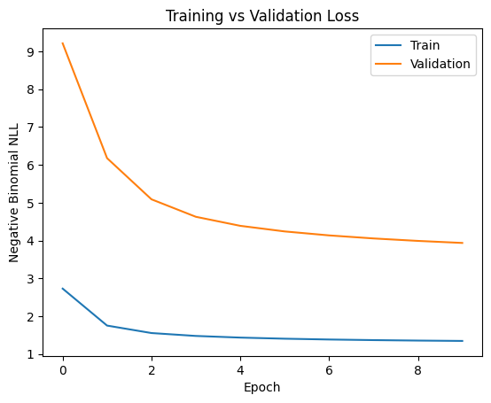

```python
import matplotlib.pyplot as plt

plt.plot(train_losses, label="Train")
plt.plot(val_losses, label="Validation")

plt.xlabel("Epoch")
plt.ylabel("Negative Binomial NLL")
plt.title("Training vs Validation Loss")

plt.legend()
plt.show()
```

**Country Embeddings**

```python
country_weights = best_model.country_embedding.get_weights()[0]
country_names = country_lookup["COUNTRY"].values
```

**Dimension Reduction (t-SNE)**

Since the latent space has 10 dimensions (our embedding_dim in best_model), we can't graph it directly. We use t-SNE to squash those 10 dimensions into 2D while keeping "similar" countries close together.

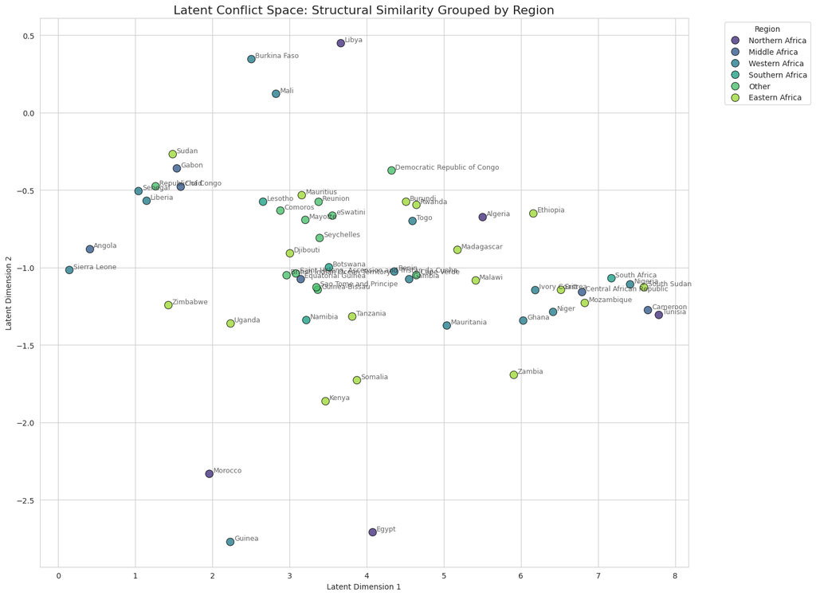

```python
from sklearn.manifold import TSNE
import matplotlib.pyplot as plt
import seaborn as sns
import pandas as pd

# 1. Define the Region Mapping
# Note: Ensure all names match exactly what is in your 'country_names' list
region_mapping = {
    'Algeria': 'Northern Africa', 'Egypt': 'Northern Africa', 'Libya': 'Northern Africa', 'Morocco': 'Northern Africa', 'Tunisia': 'Northern Africa',
    'Benin': 'Western Africa', 'Burkina Faso': 'Western Africa', 'Gambia': 'Western Africa', 'Ghana': 'Western Africa', 'Guinea': 'Western Africa', 'Ivory Coast': 'Western Africa', 'Liberia': 'Western Africa', 'Mali': 'Western Africa', 'Mauritania': 'Western Africa', 'Niger': 'Western Africa', 'Nigeria': 'Western Africa', 'Senegal': 'Western Africa', 'Sierra Leone': 'Western Africa', 'Togo': 'Western Africa',
    'Burundi': 'Eastern Africa', 'Djibouti': 'Eastern Africa', 'Eritrea': 'Eastern Africa', 'Ethiopia': 'Eastern Africa', 'Kenya': 'Eastern Africa', 'Madagascar': 'Eastern Africa', 'Malawi': 'Eastern Africa', 'Mauritius': 'Eastern Africa', 'Mozambique': 'Eastern Africa', 'Rwanda': 'Eastern Africa', 'Somalia': 'Eastern Africa', 'South Sudan': 'Eastern Africa', 'Sudan': 'Eastern Africa', 'Tanzania': 'Eastern Africa', 'Uganda': 'Eastern Africa', 'Zambia': 'Eastern Africa', 'Zimbabwe': 'Eastern Africa',
    'Angola': 'Middle Africa', 'Cameroon': 'Middle Africa', 'Central African Republic': 'Middle Africa', 'Chad': 'Middle Africa', 'Congo': 'Middle Africa', 'DRC': 'Middle Africa', 'Equatorial Guinea': 'Middle Africa', 'Gabon': 'Middle Africa',
    'Botswana': 'Southern Africa', 'Lesotho': 'Southern Africa', 'Namibia': 'Southern Africa', 'South Africa': 'Southern Africa', 'Eswatini': 'Southern Africa'
}

# 2. Run t-SNE
tsne = TSNE(n_components=2, perplexity=min(30, len(country_names)-1), random_state=42)
embeddings_2d = tsne.fit_transform(country_weights)

# 3. Prepare Dataframe for Seaborn
plot_df = pd.DataFrame({
    'Latent Dimension 1': embeddings_2d[:, 0],
    'Latent Dimension 2': embeddings_2d[:, 1],
    'Country': country_names
})
plot_df['Region'] = plot_df['Country'].map(region_mapping).fillna('Other')

# 4. Create the Plot
plt.figure(figsize=(15, 11))
sns.set_style("whitegrid")

scatter = sns.scatterplot(
    data=plot_df,
    x='Latent Dimension 1',
    y='Latent Dimension 2',
    hue='Region',
    palette='viridis',
    s=100,
    alpha=0.8,
    edgecolor='black'
)

# Add labels for each country
for i, name in enumerate(country_names):
    plt.annotate(name, (embeddings_2d[i, 0], embeddings_2d[i, 1]),
                 fontsize=9, alpha=0.7, xytext=(5,2), textcoords='offset points')

plt.title("Latent Conflict Space: Structural Similarity Grouped by Region", fontsize=16)
plt.legend(title='Region', bbox_to_anchor=(1.05, 1), loc='upper left')
plt.tight_layout()
plt.show()
```

As one can see, the latent factors aren't as simple as geography. The model is capturing other importent country regime factors.